# NCRMP Time Series File

Taylor Gill

2025-03-06

### SeaFET Data Time Frames by Location:

UNK 8/19/20- 8/16/21

UKO1 3/4/16-5/26/16

UKO 9/24/15-1/14/16

UKI 10/7/15-3/3/16

LKO1 3/2/16-5/23/16, 8/22/16-12/13/16

LKI1 9/22/15-5/24/16, 9/22/16-12/10/16

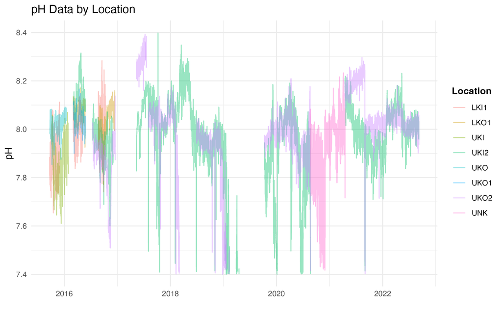

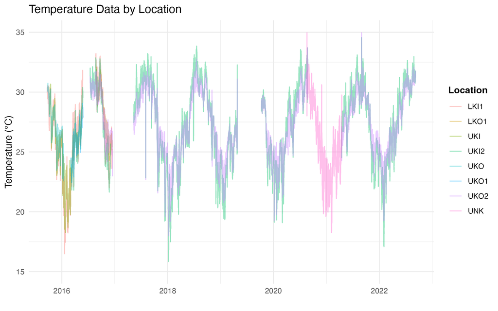

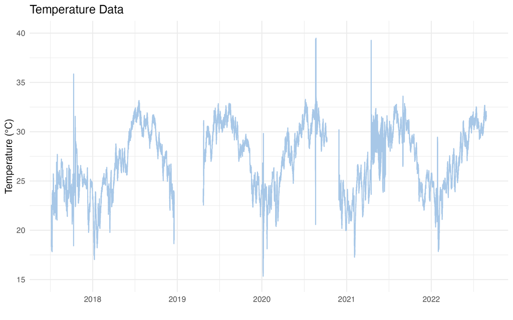

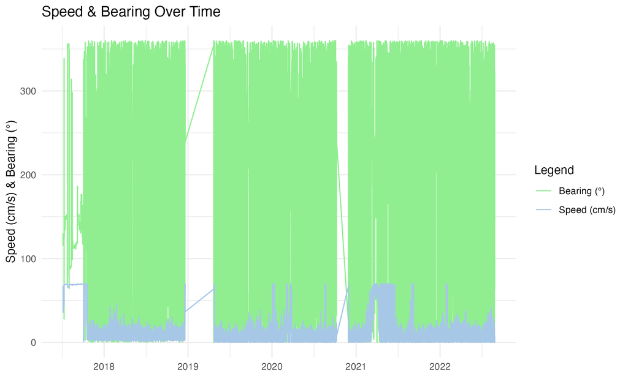

### EcoPAR Data Time Frames by Location:

LKI1 3/2/16-5/23/16, 8/22/16-12/14/16

LKI2 3/3/16-5/25/16

LKO1 3/2/16-5/23/16, 8/22/16-12/14/16

UKI2 7/14/16-7/21/16, 12/15/16-9/8/17,10/31/17-9/19/20,4/16/21-8/31/21, 1/27/22-8/11/22

UKO1 3/3/16-5/26/16

UKO2 7/14/16-2/10/17,2/21/17-8/19/20,8/31/21-9/7/22

buoy 12/15/16-12/8/17, 6/29/18-11/28/18,12/17/18-8/19/20,4/16/21-9/10/21,1/27/22-8/26/22

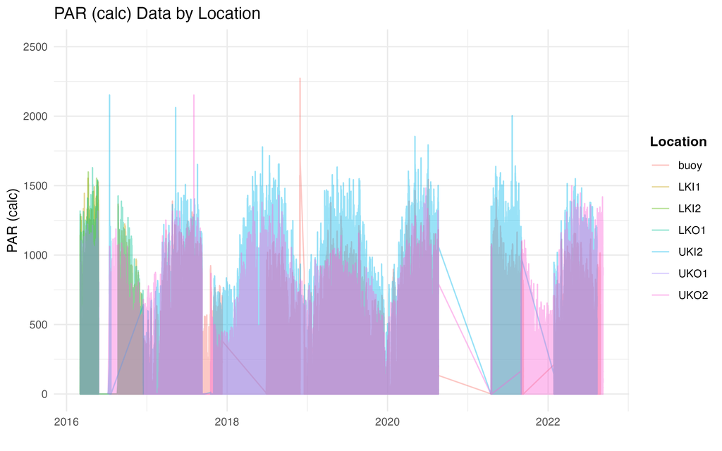